# AcceptReject: An R Package for Acceptance-Rejection Method

## 5 Function details and package usage

The AcceptReject package provides functions not only to generate observations using ARM in an optimized manner, but it also exports auxiliary functions that allow inspecting the base density function $g_Y$, as well as the generation of pseudo-random observations after the creation, making the generation and inspection work efficient, easy, and intuitive. Efficient from a computational point of view by automatically optimizing the constant $c$ and, therefore, maximizing the acceptance probability $1/c$ of accepting observations of $Y$ as observations of $X$, in addition to allowing multicore parallelism in Unix-based operating systems. The computational efficiency combined with the ease of inspecting $g_Y$ and the generated observations makes the package pleasant to use. The AcceptReject library provides the following functions:

- [`inspect()`](https://prdm0.github.io/AcceptReject/reference/inspect.html): a useful function for inspecting the probability density function $f_X$ with the base probability density function $g_Y$, highlighting the intersection between the two functions and the value of the areas, allowing experimentation with different values of $c$. This function does not perform any optimization; it simply facilitates the inspection of the proposed $g_Y$ as a base probability density function, returning an object of the secondary class `gg` and the primary class `ggplot` for graphs created with the ggplot2 library, as shown in Figure 1 (a) and Figure 1 (b);
- [`accept_reject()`](https://prdm0.github.io/AcceptReject/reference/accept_reject.html): implements ARM, optimizes the constant $c$, and performs parallelism if specified by the user. The user can also specify details in the optimization process or define a value for $c$ and thus assume this value of $c$, omitting the optimization process. Additionally, it is possible to specify or not a base probability mass function or probability density function $g_Y$, depending on whether $X$ is a discrete or continuous random variable, respectively. If omitted, $Y \sim \mathcal{U}$ discrete or continuous will be considered, depending on the nature of $X$. Moreover, the user can specify, in the case of not specifying the value of the constant $c$, an initial guess used in the optimization process of the constant $c$. A good guess can be given by graphically inspecting the relationship between $f_X$ and $g_Y$. In most cases, the `accept_reject()` function will provide good acceptances without specifying $g_Y$ different from the default discrete or continuous uniform distribution and will make a good estimation of $c$;
- [`print.accept_reject()`](https://prdm0.github.io/AcceptReject/reference/print.accept_reject.html): a function responsible for printing useful information on the screen about objects of the `accept_reject` class returned by the [`accept_reject()`](https://prdm0.github.io/AcceptReject/reference/accept_reject.html) function, such as the number of generated observations, the estimated constant $c$, and the estimated acceptance probability of accepting observations of $Y$ as observations of $X$;
- [`plot.accept_reject()`](https://prdm0.github.io/AcceptReject/reference/plot.accept_reject.html): operates on objects of the `accept_reject` class returned by the [`accept_reject()`](https://prdm0.github.io/AcceptReject/reference/accept_reject.html) function. The [`plot.accept_reject()`](https://prdm0.github.io/AcceptReject/reference/plot.accept_reject.html) function returns an object of the secondary class `gg` and the primary class `ggplot` from the ggplot2 package, allowing easy graphical comparison of the probability density function or probability mass function $f_X$ with the observed probability density function or mass function from the generated data;
- [`qqplot()`](https://prdm0.github.io/AcceptReject/reference/qqplot.html): constructs a Quantile-Quantile plot (QQ-plot) to compare the distribution of data generated by ARM (observed distribution) with the distribution of the random variable $X$ (theoretical distribution, denoted by $f_X$). In a very simple way, the QQ-plot is produced by passing an object of the `accept_reject` class, returned by the `accept_reject()` function, to the `qqplot()` function.

In the following subsections, more details about the functions exported by the AcceptReject package will be presented. Examples are provided to facilitate understanding. Additional details about the functions can be found in the function documentation, which can be accessed using `help(package = "AcceptReject")` or on the package’s website, hosted in the GitHub repository that versions the development of the library at https://prdm0.github.io/AcceptReject/.

### 5.1 Inspecting Density Functions

The [`inspect()`](https://prdm0.github.io/AcceptReject/reference/inspect.html) function of the AcceptReject package is useful when we want to generate pseudo-random observations of a continuous random variable using ARM. It is possible to skip this inspection since the `accept_reject()` function already automatically considers the continuous uniform distribution as the base density and optimizes, based on this base distribution, the best value for the constant $c$. Additionally, other base densities $g_Y$ can be specified to the `accept_reject()` function, where the search for the constant $c$ will be done automatically, optimizing the value of $c$ and its relationship with $f_X$ and $g_Y$, given $g_Y$.

To specify other base density functions $g_Y$, it is prudent to perform a graphical inspection of the relationship between $f_X$ and $g_Y$ to get an idea of the reasonableness of the candidate base probability density function $g_Y$. Thus, the `inspect()` function will automatically plot a graph with some useful information, as well as the functions $f_X$ and $g_Y$. The `inspect()` function will return an object with the secondary class `gg` and the primary class `ggplot` (a graph made with the ggplot2 library) highlighting the intersection area between $f_X$ and $g_Y$ and the value of this area for a given $c$, specified in the `c` argument of the `inspect()` function.

Theoretically, you can use any function $g_Y$ that has support equivalent to that of the function $f_X$, finding the appropriate value of $c$ that will make $g_Y$ envelop $f_X$, that is, so that the value of the intersection area integrates to 1. The `inspect()` function has the following form:

```r
inspect(
  f,
  args_f,
  f_base,
  args_f_base,
  xlim,
  c = 1,
  alpha = 0.4,
  color_intersection = "#BB9FC9",
  color_f = "#FE4F0E",
  color_f_base = "#7BBDB3"
)
```

where:

1. `f` is the probability density function $f_X$ of the random variable $X$ of interest;
2. `args_f`: is a list of arguments that will be passed to the probability density function $f_X$ and that specify the parameters of the density of $X$;
3. `f_base`: is the probability density function that will supposedly be used as the base density $g_Y$;
4. `args_f_base`: is a list of arguments that will be passed to the base probability density function $g_Y$ and that specify the parameters of the density of $Y$;
5. `xlim`: is a vector of size two that specifies the support of the functions $f_Y$ and $g_Y$ (they must be equivalent);
6. `c`: is the constant $c$ that will be used to multiply the base probability density function $g_Y$, so it envelops (bounds) $f_X$. The default is `c = 1`;
7. `alpha`: is the transparency of the intersection area (default is `alpha = 0.4`);
8. `color_intersection`: is the color of the intersection area between $f_X$ and $g_Y$, where the default is `color_intersection = #BB9FC9`;
9. `color_f`: is the color of the curve of the probability density function $f_X$ (default is `color_f = #FE4F0E`);
10. `color_f_base`: is the color of the curve of the base probability density function $g_Y$, where the default is `color_f_base = #7BBDB3`.

The Figure 1 (a) and Figure 1 (b), presented at the beginning of this paper, were automatically created with the [`inspect()`](https://prdm0.github.io/AcceptReject/reference/inspect.html) function. As an example, in addition to those available in the package documentation and vignettes, here is the code that generated the graph shown in Figure 1 (a):

```r
library(AcceptReject)

# Considering c = 1 (default)
inspect(
  f = dweibull,
  f_base = dunif,
  xlim = c(0, 5),
  args_f = list(shape = 2, scale = 1),
  args_f_base = list(min = 0, max = 5),
  c = 1
)
```

### 5.2 Generating Observations with ARM

The most important function of the AcceptReject package is the `accept_reject()` function, as it is the function that implements ARM and all the optimizations to obtain a good generation of $X$. The `accept_reject()` function has the following signature:

```r
accept_reject(
  n = 1L,
  continuous = TRUE,
  f = NULL,
  args_f = NULL,
  f_base = NULL,
  random_base = NULL,
  args_f_base = NULL,
  xlim = NULL,
  c = NULL,
  parallel = FALSE,
  cores = NULL,
  warning = TRUE,
  ...
)
```

In a simpler use case, where the user does not wish to specify the base density function $g_Y$ passed as an argument to `f_base`, useful for generating observations of a sequence of continuous random variables ($x_1, \cdots, x_n$), the use of the `accept_reject()` function is quite straightforward. For example, to generate 100 observations of a random variable $X$ with a probability density function $f_X(x) = 2x$, $0 \leq x \leq 1$, the user could do:

```r
set.seed(0)

# Generate 100 observations from a random variable X with
# f_X(x) = 2x, 0 <= x <= 1.
x <- accept_reject(
  n = 100L,
  f = function(x) 2 * x,
  args_f = list(),
  xlim = c(0, 1),
  warning = FALSE
)
print(x[1L:8L])
```

```
[1] 0.8966972 0.3721239 0.5728534 0.8983897 0.9446753 0.6607978
[7] 0.6870228 0.7698414
```

Note that in this case, if `warning = TRUE` (default), the `accept_reject()` function cannot know that `xlim = c(0, 1)` specifies the entire support of the probability density function $f_X(x) = 2x$, $0 \leq x \leq 1$, and that is why it issues a warning. Typically, one chooses a support that is passed to the `xlim` argument in which below the lower limit (first element of `xlim`) and above the upper limit (second element of the vector `xlim`), the probability mass (in the discrete case) or density (in the continuous case) is close to zero or not defined. In this case, we have deliberately set `warning = FALSE`.

### 5.3 Printing the Object with Generated Observations

The `accept_reject()` function returns an object of class `accept_reject`. An object of the `accept_reject` class is essentially an atomic vector with observations generated by ARM, carrying attributes and marked with a specific class from the AcceptReject package, i.e., marked with the `accept_reject` class. These attributes are useful for the package and carry information used by the `plot.accept_reject()` function.

Using the S3 object-oriented system in R, the `print()` function will dispatch for objects of the `accept_reject()` class, invoking the `print.accept_reject()` method from the AcceptReject package. For an object of the `accept_reject` class returned by the `accept_reject()` function, it is possible to pass methods that operate on atomic vectors, such as `summary()`, `mean()`, `var()`, among others. The `print()` function will print useful information about the `accept_reject()` class object, such as the number of observations generated, the value of `c` used, the acceptance probability, the first generated observations, and the considered `xlim` interval. The `summary()` function will work by returning some descriptive statistics about the generated observations, such as the mean, median, variance, standard deviation, minimum, maximum, first quartile, and third quartile.

```r
# setting a seed for reproducibility
set.seed(0)
x <- accept_reject(
   n = 2000L,
   f = dbinom,
   continuous = FALSE,
   args_f = list(size = 5, prob = 0.5),
   xlim = c(0, 10)
)

# Printing the first 10 (default) observations
print(x)
```

[output not shown]

```r
# Printing the first 20 observations
print(x, n_min = 20L)
```

[output not shown]

```r
# Summary
summary(x)
```

```
       V1
 Min.   :0.000
 1st Qu.:2.000
 Median :3.000
 Mean   :2.538
 3rd Qu.:3.000
 Max.   :5.000
```

### 5.4 Plotting Data Generated by ARM

Often, when generating observations using ARM, we are interested in visualizing the generated observations and graphically comparing them with the probability mass function (discrete case) or probability density function (continuous case) to get an idea of the quality of the data generation. Constructing a graph with your favorite library for each generation can be time-consuming. The idea of the `plot.accept_reject()` method is to facilitate this task, allowing you to easily and quickly generate this type of graph. In fact, since the S3 object-oriented system is used, you only need to use the `plot()` function on an `accept_reject` class object.

The `plot()` function applied to an `accept_reject` class object will return an object with the secondary class `gg` and the primary class `ggplot` (returns a graph). The returned object is a graph constructed with the ggplot2 library and can be modified to your preferred ggplot2 standards, such as its theme. However, the `plot` function has some specific arguments that allow you to modify some elements. The general usage form is:

```r
## S3 method for class 'accept_reject'
plot(
  x,
  color_observed_density = "#BB9FC9",
  color_true_density = "#FE4F0E",
  color_bar = "#BB9FC9",
  color_observable_point = "#7BBDB3",
  color_real_point = "#FE4F0E",
  alpha = 0.3,
  hist = TRUE,
  ...
)
```

1. `x`: An object of the `accept_reject` class;
2. `color_observed_density`: observed density color (continuous case);
3. `color_true_density`: theoretical density color (continuous case);
4. `color_bar`: bar chart fill color (discrete case);
5. `color_observable_point`: color of generated points (discrete case);
6. `color_real_point`: color of the real points (discrete case);
7. `alpha`: transparency of the bars (discrete case);
8. `hist`: if `TRUE`, a histogram will be plotted in the continuous case, comparing the theoretical density with the observed one. If `FALSE`, `ggplot2::geom_density()` will be used instead of the histogram;
9. `...`: additional arguments.

The following code demonstrates the use of the `plot()` function. In Figure 3 (a), an example of a graph is presented with the histogram replaced by the observed density, if this type of representation is more useful to the user. To do this, simply pass the argument `hist = FALSE`. To illustrate the use of the arguments, the parameters `color_true_density`, `color_observed_density`, and `alpha` were also changed. In Figure 3 (b), an example of generating a graph for the discrete case is presented. The simple use of the `plot()` function without passing arguments should be sufficient to meet the needs of most users.

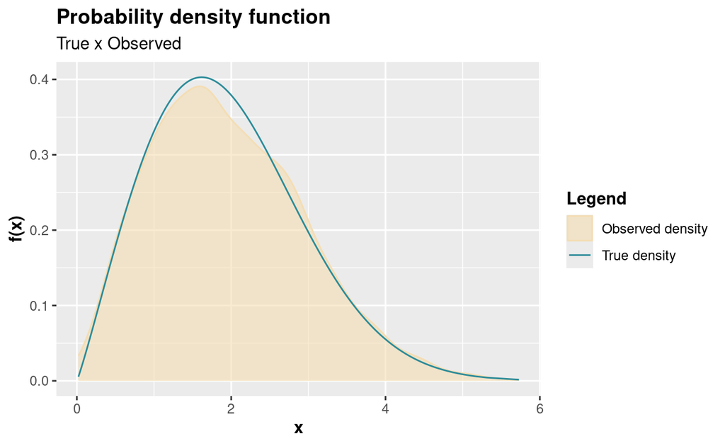

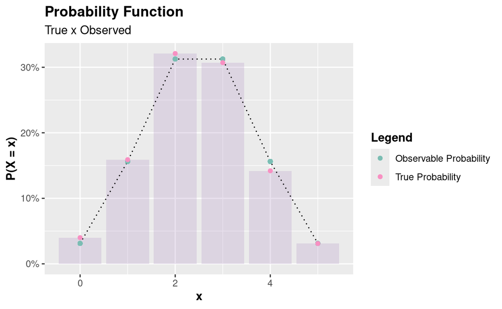

Figure 3: Plotting the theoretical density function (a) and the probability mass function (b), with details of the respective parameters in the code.

```r
library(AcceptReject)

# Generating and plotting the theoretical density with the
# observed density.

# setting a seed for reproducibility
set.seed(0)

# Continuous case
accept_reject(
  n = 2000L,
  continuous = TRUE,
  f = dweibull,
  args_f = list(shape = 2.1, scale = 2.2),
  xlim = c(0, 10)
) |>
  plot(
    hist = FALSE,
    color_true_density = "#2B8b99",
    color_observed_density = "#F4DDB3",
    alpha = 0.6
  ) # Changing some arguments in plot()

# Discrete case
accept_reject(
  n = 1000L,
  f = dbinom,
  continuous = FALSE,
  args_f = list(size = 5, prob = 0.5),
  xlim = c(0, 10)
) |> plot()
```

## 6 Examples

Below are some examples of using the `accept_reject()` function to generate pseudo-random observations of discrete and continuous random variables. It should be noted that in the case of $X$ being a discrete random variable, it is necessary to provide the argument `continuous = FALSE`, whereas in the case of $X$ being continuous (the default), you must consider `continuous = TRUE`.

### 6.1 Generating discrete observations

As an example, let $X \sim Poisson(\lambda = 0.7)$. We will generate $n = 1000$ observations of $X$ using the acceptance-rejection method, using the `accept_reject()` function. Note that it is necessary to provide the `xlim` argument. Try to set an upper limit value for which the probability of $X$ assuming that value is zero or very close to zero. In this case, we choose `xlim = c(0, 20)`, where `dpois(x = 20, lambda = 0.7)` is very close to zero (1.6286586^{-22}). Note Figure 4 (a) and Figure 4 (b), respectively, and note that in Figure 4 (b), there is a proximity of the observed probabilities to the theoretical probabilities, indicating that ARM is generating observations that approximate the true probability mass function as the sample size increases.

```r
library(AcceptReject)
library(parallel)
library(cowplot) # install.packages("cowplot")

# Ensuring reproducibility in parallel computing
RNGkind("L'Ecuyer-CMRG")
set.seed(0)
mc.reset.stream()

# Simulation
simulation <- function(n, lambda = 0.7)
  accept_reject(
    n = n,
    f = dpois,
    continuous = FALSE, # discrete case
    args_f = list(lambda = lambda),
    xlim = c(0, 20),
    parallel = TRUE # Parallelizing the code in Unix-based systems
)

# Generating observations
# n = 25 observations
system.time({x <- simulation(25L)})
```

```
   user  system elapsed
  0.004   0.203   0.205
```

```r
plot(x)

# n = 2500 observations
system.time({y <- simulation(2500L)})
```

```
   user  system elapsed
  0.006   0.191   0.197
```

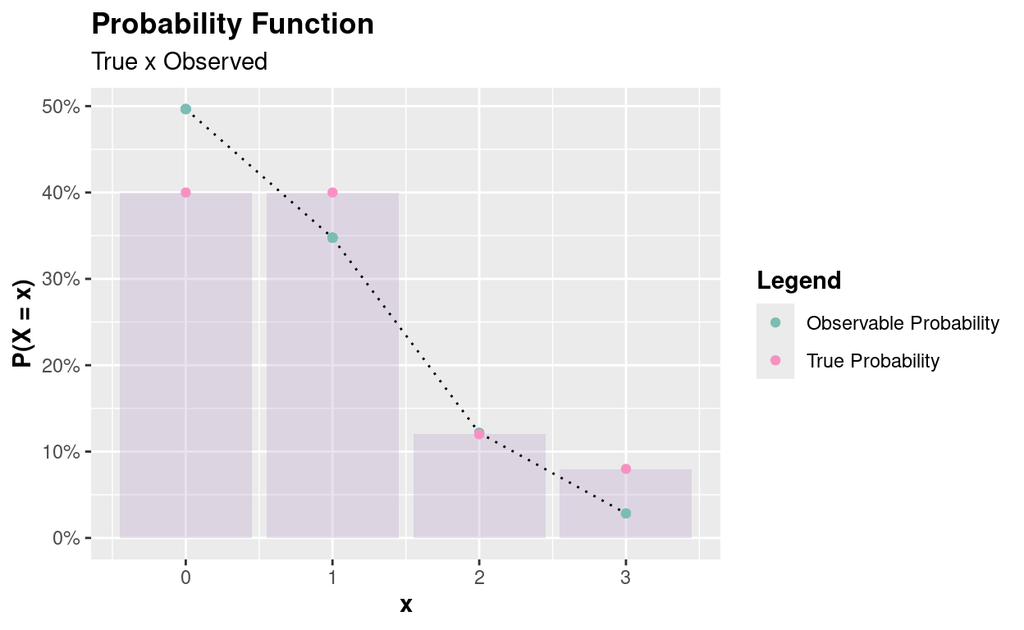

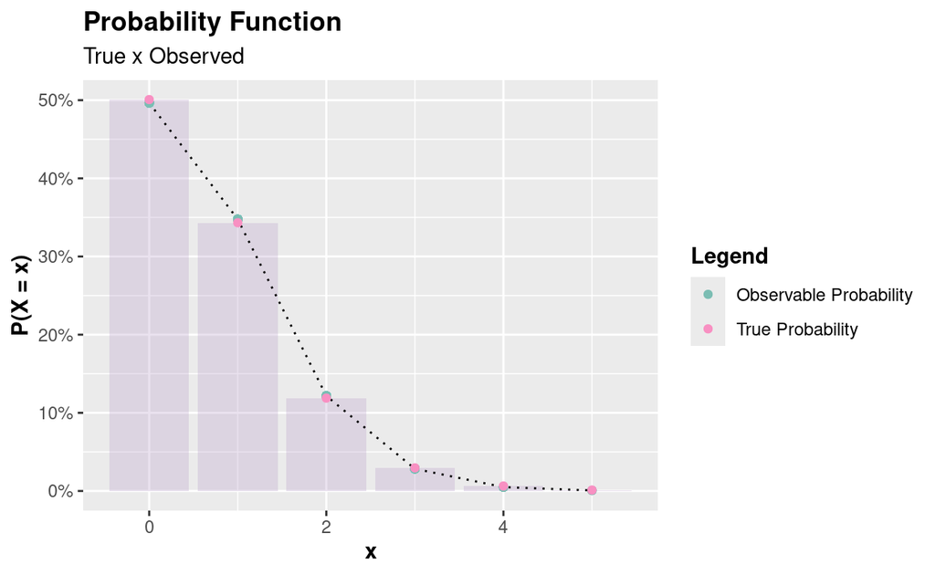

Figure 4: Generating observations from a Poisson distribution using the acceptance-rejection method, with $n = 25$ (a) and $n = 2500$ (b), respectively.

```r
plot(y)
```

Note that it is necessary to specify the nature of the random variable from which observations are desired to be generated. In the case of discrete variables, the argument `continuous = FALSE` must be passed. In Section 6, examples of how to generate continuous observations will be presented.

### 6.2 Generating continuous observations

Considering the default base function, which is the uniform distribution, where it is not necessary to specify it, the code below exemplifies the continuous case, where $X \sim \mathcal{N}(\mu = 0, \sigma^2 = 1)$. Not specifying a base probability density function implies `f_base = NULL`, `random_base = NULL`, and `args_base = NULL`, which are the defaults for the `accept_reject()` function. If at least one of them is specified as `NULL` and, by mistake, another is specified, no error will occur. In this situation, the `accept_reject()` function will assume the base probability density function is the density function of a uniform distribution over `xlim`. Note also the use of the `plot()` function, which generates a graph with the theoretical density function and the histogram of the generated observations, allowing a quick visual check of the quality of the observations generated by ARM.

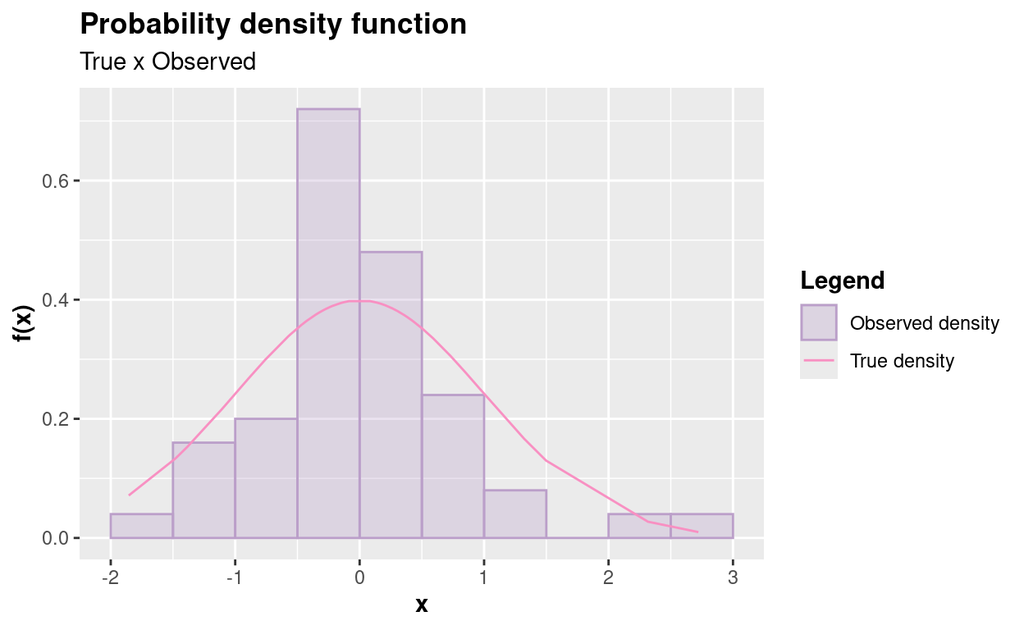

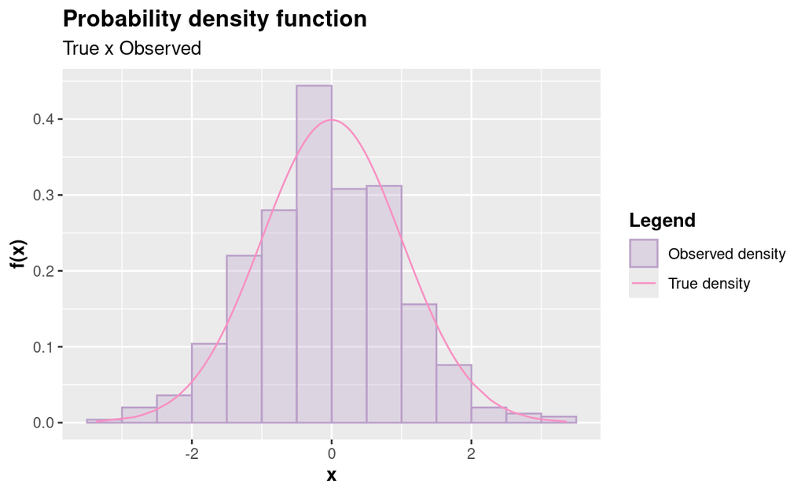

Figure 5: Generating observations from a continuous random variable with a Standard Normal distribution, with $n = 50$ and $n = 500$ observations, respectively.

```r
library(AcceptReject)
library(parallel)

# Ensuring reproducibility in parallel computing
RNGkind("L'Ecuyer-CMRG")
set.seed(0)
mc.reset.stream()

# Generating observations
accept_reject(
  n = 50L,
  f = dnorm,
  continuous = TRUE,
  args_f = list(mean = 0, sd = 1),
  xlim = c(-4, 4),
  parallel = TRUE
) |> plot()

accept_reject(
  n = 500L,
  f = dnorm,
  continuous = TRUE,
  args_f = list(mean = 0, sd = 1),
  xlim = c(-4, 4),
  parallel = TRUE
) |> plot()
```

## 7 A practical scenario for the use of the package

So far, the use of the package to generate distributions that are relatively simple and involve few parameters has been demonstrated. In this section, the idea is to demonstrate the use of the AcceptReject package in a practical situation where the use of ARM becomes necessary. Let’s consider the generator of Modified Beta Distributions, proposed by (Nadarajah et al. 2014). It is a family of probability distributions since it is possible to generate various probability density functions through the proposed density generator, whose general density function is defined by:

$$f_X(x) = \frac{\beta^a}{B(a,b)} \times \frac{g(x)G(x)^{a - 1}(1 - G(x))^{b - 1}}{[1 - (1 - \beta)G(x)]^{a + b}},$$
with $x \geq 0$ and $\beta, a, b > 0$, where $g(x)$ is a probability density function, $G(x)$ is the cumulative distribution function of $g(x)$, and $B(a,b)$ is the beta function.

```r
library(numDeriv)

pdf <- function(x, G, ...){
  numDeriv::grad(
    func = \(x) G(x, ...),
    x = x
  )
}

# Modified Beta Distributions
# Link: https://link.springer.com/article/10.1007/s13571-013-0077-0
generator <- function(x, G, a, b, beta, ...){
  g <- pdf(x = x, G = G, ...)
  numerator <- beta^a * g * G(x, ...)^(a - 1) * (1 - G(x, ...))^(b - 1)
  denominator <- beta(a, b) * (1 - (1 - beta) * G(x, ...))^(a + b)
  numerator/denominator
}

# Probability density function - Modified Beta Weibull
pdf_mbw <- function(x, a, b, beta, shape, scale)
  generator(
    x = x,
    G = pweibull,
    a = a,
    b = b,
    beta = beta,
    shape = shape,
    scale = scale
  )

# Checking the value of the integral
integrate(
  f = \(x) pdf_mbw(x, 1, 1, 1, 1, 1),
  lower = 0,
  upper = Inf
)
```

```
1 with absolute error < 5.7e-05
```

Notice that the value `pdf_mbw()` integrates to 1, being a probability density function. Thus, the `generator()` function generates probability density functions based on another distribution $G_X(x)$. In the case of the code above, the cumulative distribution function of the Weibull distribution is passed to the `generator()` function, but it could be any other.

In the following code, we will adopt the strategy of investigating (inspecting) a coherent proposal for a base density function to be passed as an argument to `f_base` in the `accept_reject()` function. The investigation could be skipped, in which case the `accept_reject()` function would assume the uniform distribution as the base.

We will consider the Weibull distribution since it is a particular case of the Modified Beta Weibull distribution. As we know how to generate observations from the Weibull distribution using the `rweibull()` function, the Weibull distribution is a viable candidate for the base density $g_Y(y)$. Consider the true parameters `a = 10.5`, `b = 4.2`, `beta = 5.9`, `shape = 1.5`, and `scale = 1.7`. Thus, using the `inspect()` function, we can quickly inspect by doing:

```r
library(AcceptReject)

# True parameters
a <- 10.5
b <- 4.2
beta <- 5.9
shape <- 1.5
scale <- 1.7

# c = 1 (default)
inspect(
  f = pdf_mbw,
  f_base = dweibull,
  xlim = c(0, 4),
  args_f = list(
    a = a,
    b = b,
    beta = beta,
    shape = shape,
    scale = scale
  ),
  args_f_base = list(shape = 2, scale = 1.2),
  c = 1
)

# c = 2.2
inspect(
  f = pdf_mbw,
  f_base = dweibull,
  xlim = c(0, 4),
  args_f = list(
    a = a,
    b = b,
    beta = beta,
    shape = shape,
    scale = scale
  ),
  args_f_base = list(shape = 2, scale = 1.2),
  c = 2.2
)
```

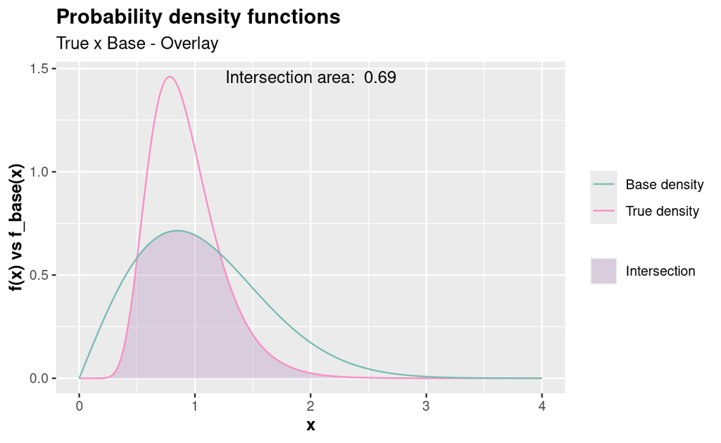

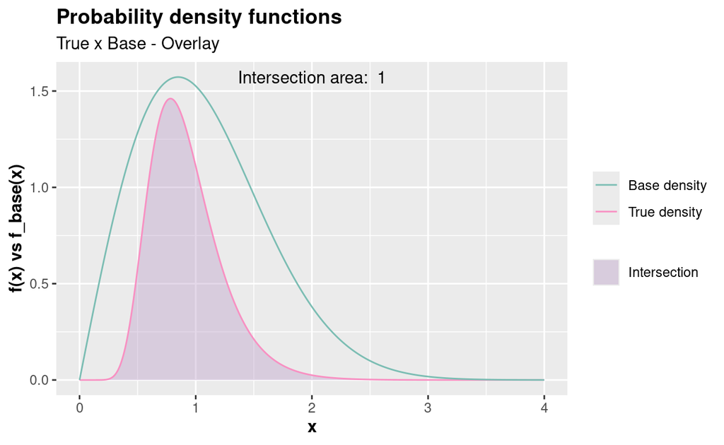

Figure 6: Inspecting the Weibull distribution with shape = 2, scale = 1.2, with the support xlim = c(0, 4) and c = 1 (default) (a) and c = 2.2 (b), respectively.

Notice that in Figure 6 (b), when $c = 2.2$, the density $g_Y$ bounds the density $f_X$, which is the Modified Beta Weibull density of $X$ from which we want to generate observations. Thus, the density $g_Y$ used as a base is a viable candidate to be passed to the `f_base` argument of the `accept_reject()` function in the AcceptReject package. Also, note that the area between $f_X$ and $g_Y$ is smaller than it would be if $g_Y$ were considered the uniform probability density function in the `xlim` support. In the following section, we will discuss the computational cost for different sample sizes, considering the base density $g_Y$ as the Weibull density or the default (uniform density).

## 8 Benchmarking

The benchmarks considered in this section were performed on a computer with Arch Linux operating system, Intel Core(TM) i7-1260P processor with 16 threads, maximum frequency of 4.70 GHz, with computational times in logarithmic scale, base ten. More specifications were presented in Section 3.

Considering the case of the Modified Beta Weibull probability density function (a probability density function with five parameters) implemented in the `pdf_mbw()` function presented in Section 7, several benchmarks were conducted to evaluate the computational cost of the `accept_reject()` function for various sample sizes, considering both the parallelized and non-parallelized scenarios. Additionally, the benchmarks took into account the specification of $g_Y$ considering the continuous uniform distribution in the `xlim` interval (default of the `accept_reject()` function) and the Weibull distribution with parameters `shape = 2` and `scale = 1.2`, which bounds the probability density function of a random variable with Modified Beta Weibull with true parameters as in Figure 6. The sample sizes considered were $n = 50$, $250$, $500$, $1000$, $5000$, $10000$, $15000$, $25000$, $50000$, $100000$, $150000$, $250000$, $500000$, and $1000000$.

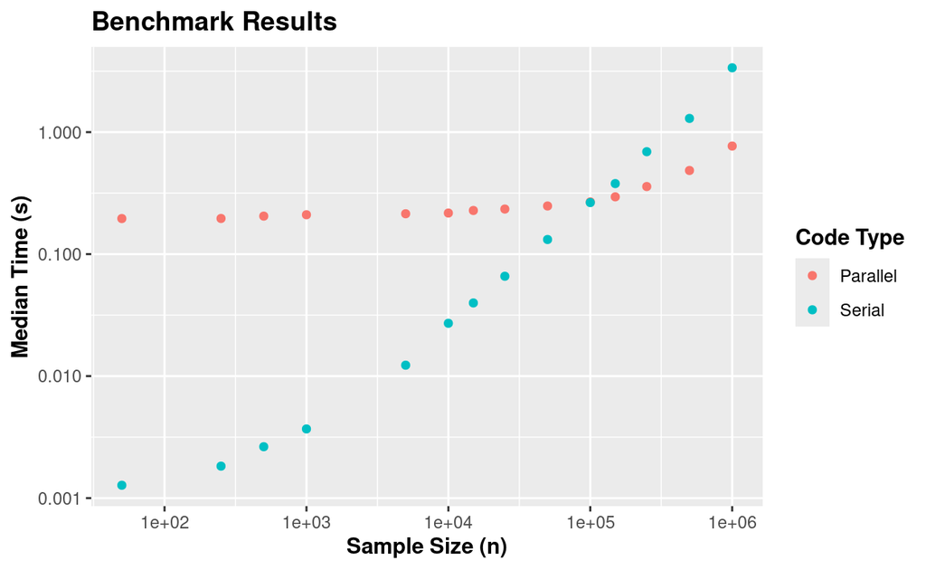

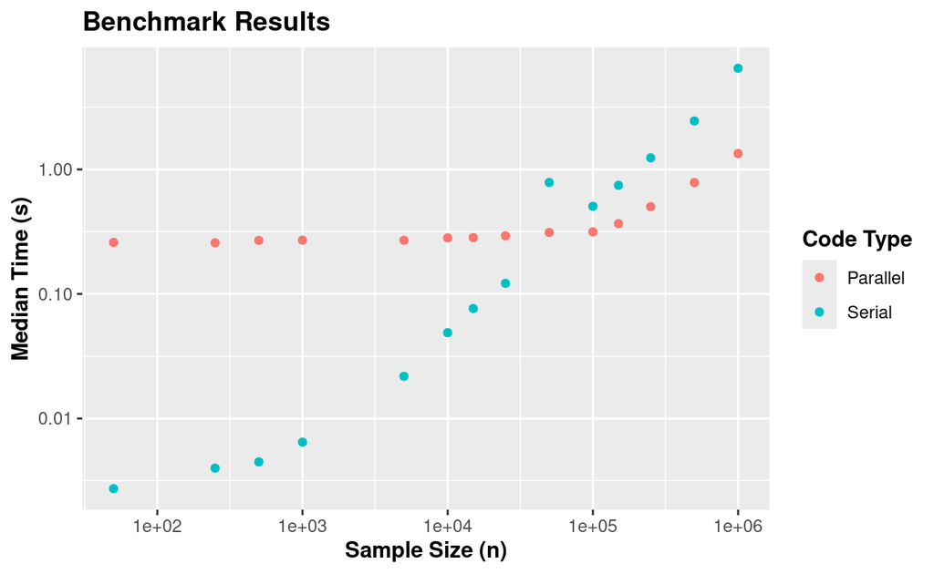

Figure 7: Benchmarking for different sample sizes, considering the Weibull distribution and the uniform distribution as the base density, with Weibull distribution and Uniform distribution (default), respectively.

It can be observed Figure 7 that the choice of the base distribution, for the simulated case, did not significantly influence the computational performance of the `accept_reject()` function. Often, depending on the complexity of $f_X$, the user might not need to worry about choosing a $g_Y$ to pass to the `f_base` argument of the `accept_reject()` function. Additionally, it is not very common in Monte-Carlo simulation studies to consider sample sizes much larger than those considered here. Therefore, users of non-Unix-based systems will not experience significant issues regarding the computational cost of the `accept_reject()` function.

## 9 Related works

An implementation of ARM is provided by the AR library (Parchami 2018). This library exports the `AR.Sim()` function, which has an educational utility to demonstrate the functioning of ARM. Additionally, the design of the AcceptReject package allows, in the continuous case, the use of base probability density functions that do not necessarily need to be implemented in the R language or in specific packages like in the case of the AR library, which is a significant advantage. The specifications of the base densities in the AR package are made considering only the densities implemented in the DISTRIB package (Parchami 2016).

Another library that implements ARM is SimDesign (Chalmers and Adkins 2020), through the `rejectionSampling()` function. The `rejectionSampling()` function is more efficient than the `AR.Sim()` function from the AR library, but its efficiency still does not surpass that of the `accept_reject()` function from the AcceptReject package. The `rejectionSampling()` function from the SimDesign library also does not support parallelism, which is a disadvantage compared to the `accept_reject()` function from the AcceptReject package. Furthermore, the design of the AcceptReject package uses the S3 object-oriented system, with exports of simple functions that allow the inspection and analysis of the generated data.

The AcceptReject library presents several advantages over the mentioned libraries, particularly in the way the package is designed, facilitating the use of functions. The library, for example, provides functions that allow the inspection of $f_X$ with $g_Y$ when $X$ and $Y$ are continuous random variables, making it easy to create highly informative graphs for the user, visually informing about the quality of the generated observations. It is a common interest for those using ARM to observe the generated data and check if they conform to the desired probability distribution.

Figure 8 (a) presents a simulation study comparing the `accept_reject()` function from the AcceptReject package with the `rejectionSampling()` function from the SimDesign package, considering small to moderate sample sizes. In this scenario, the `accept_reject()` function was executed serially, just like the `rejectionSampling()` function, which does not support parallelism. Equivalent performance was observed between the functions. In Figure 8 (b), it is observed that the performance of the `accept_reject()` function on large samples, considering the parallel execution of the `accept_reject()` function, surpasses the performance of the `rejectionSampling()` function from the SimDesign package.

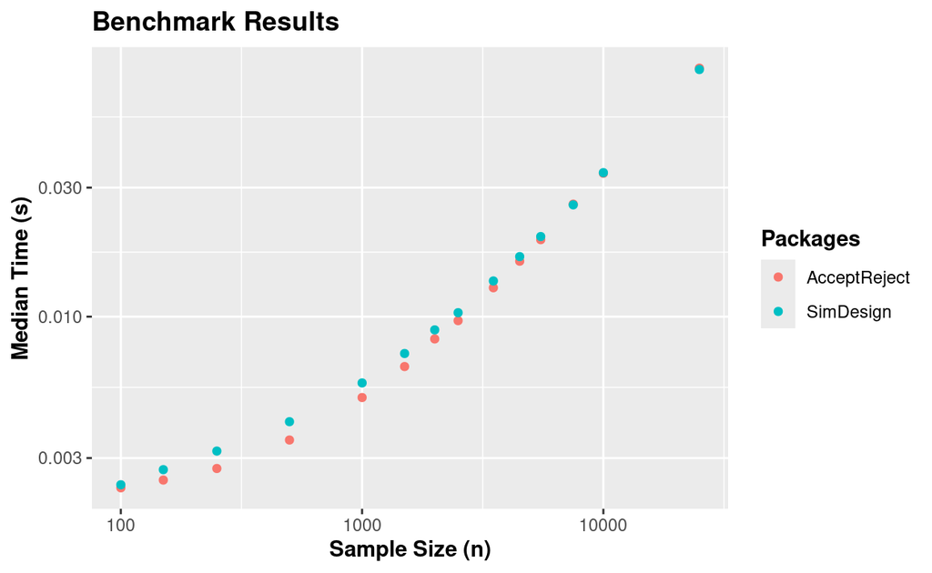

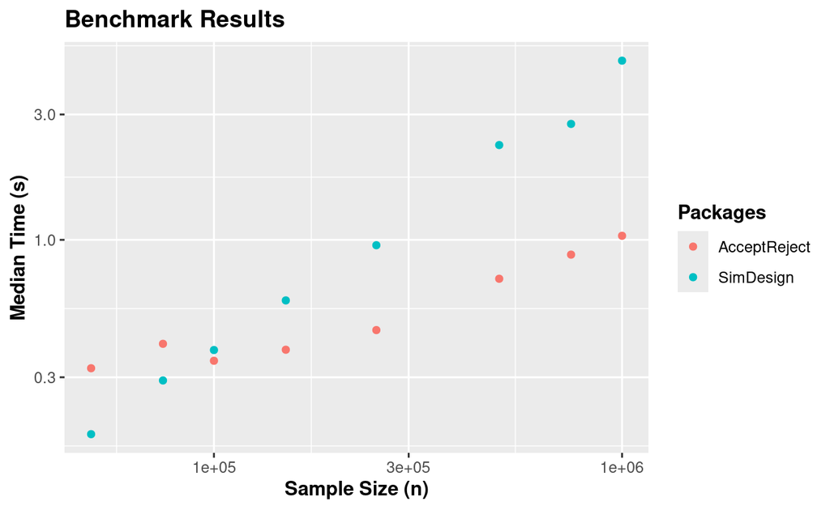

Figure 8: Comparison between the AcceptReject and SimDesign package for different sample sizes, considering the generation of observations from a random variable with a Modified Beta Weibull distribution, serial processing with AcceptReject (a) and parallel processing with AcceptReject package (b), respectively.

## 10 Conclusion and future developments

The AcceptReject package is an efficient tool for generating pseudo-random numbers in univariate distributions of discrete and continuous random variables using the acceptance-rejection method (ARM). The library is built with the aim of delivering ease of use and computational efficiency. The AcceptReject library can generate pseudo-random numbers both serially and in parallel, with computational efficiency in both cases, in addition to allowing easy inspection and analysis of the generated data.

For future developments, the AcceptReject library can be extended with functions that allow the visualization of ARM in an iterative application using Shiny for educational purposes. The most important development step for future versions will be to seek even more performance. Additionally, the project is also open to contributions from the community.

### 10.1 Supplementary materials

Supplementary materials are available in addition to this article. It can be downloaded at RJ-2025-037.zip

### 10.2 CRAN packages used

AcceptReject, Rcpp, RcppArmadillo, assertthat, cli, ggplot2, glue, numDeriv, purrr, rlang, scales, scattermore, knitr, rmarkdown, cowplot, testthat, magrittr, parallel, AR, DISTRIB, SimDesign

### 10.3 CRAN Task Views implied by cited packages

ChemPhys, HighPerformanceComputing, NetworkAnalysis, NumericalMathematics, Phylogenetics, ReproducibleResearch, Spatial, TeachingStatistics

J. Allaire, Y. Xie, C. Dervieux, J. McPherson, J. Luraschi, K. Ushey, A. Atkins, H. Wickham, J. Cheng, W. Chang, et al. *rmarkdown: Dynamic documents for R.* 2024. URL https://github.com/rstudio/rmarkdown. R package version 2.26.

S. Asmussen and P. W. Glynn. *Stochastic simulation: Algorithms and analysis.* Springer, 2007.

S. M. Bache and H. Wickham. *magrittr: A forward-pipe operator for R.* 2022. URL https://CRAN.R-project.org/package=magrittr. R package version 2.0.3.

R. P. Chalmers and M. C. Adkins. Writing effective and reliable Monte Carlo simulations with the SimDesign package. *The Quantitative Methods for Psychology*, 16(4): 248–280, 2020. DOI 10.20982/tqmp.16.4.p248.

J. M. Chambers. Object-oriented programming, functional programming and R. 2014.

W. Chang. *R6: Encapsulated classes with reference semantics.* 2021. URL https://CRAN.R-project.org/package=R6. R package version 2.5.1.

G. Csárdi. *cli: Helpers for developing command line interfaces.* 2023. URL https://CRAN.R-project.org/package=cli. R package version 3.6.2.

D. Eddelbuettel, R. Francois, J. Allaire, K. Ushey, Q. Kou, N. Russell, D. Bates, J. Chambers and M. D. Eddelbuettel. Package “Rcpp”. 2024.

D. Eddelbuettel and C. Sanderson. RcppArmadillo: Accelerating R with high-performance C++ linear algebra. *Computational statistics & data analysis*, 71: 1054–1063, 2014.

J. E. Gentle. *Random number generation and Monte Carlo methods.* Springer, 2003.

P. Gilbert and R. Varadhan. *numDeriv: Accurate numerical derivatives.* 2019. URL https://CRAN.R-project.org/package=numDeriv. R package version 2016.8-1.1.

L. Henry and H. Wickham. *rlang: Functions for base types and core R and ’Tidyverse’ features.* 2024. URL https://CRAN.R-project.org/package=rlang. R package version 1.1.3.

J. Hester and J. Bryan. *glue: Interpreted string literals.* 2024. URL https://CRAN.R-project.org/package=glue. R package version 1.7.0.

D. Kemp. Discrete-event simulation: Modeling, programming, and analysis. 2003.

D. P. Kroese, T. Taimre and Z. I. Botev. *Handbook of monte carlo methods.* John Wiley & Sons, 2013.

T. Kulichova and M. Kratochvil. *scattermore: Scatterplots with more points.* 2023. URL https://CRAN.R-project.org/package=scattermore. R package version 1.2.

P. L’ecuyer. Good parameters and implementations for combined multiple recursive random number generators. *Operations Research*, 47(1): 159–164, 1999.

P. L’ecuyer, R. Simard, E. J. Chen and W. D. Kelton. An object-oriented random-number package with many long streams and substreams. *Operations research*, 50(6): 1073–1075, 2002.

P. R. D. Marinho and V. L. D. Tomazella. *AcceptReject: Acceptance-rejection method for generating pseudo-random observations.* 2024. URL https://prdm0.github.io/AcceptReject/. R package version 0.1.1.

S. Nadarajah, M. Teimouri and S. H. Shih. Modified beta distributions. *Sankhya B*, 76: 19–48, 2014.

A. Parchami. *AR: Another look at the acceptance-rejection method.* 2018. URL https://CRAN.R-project.org/package=AR. R package version 1.1.

A. Parchami. *DISTRIB: Four essential functions for statistical distributions analysis: A new functional approach.* 2016. URL https://CRAN.R-project.org/package=DISTRIB. R package version 1.0.

J. von Neumann. Various techniques used in connection with random digits. *Notes by GE Forsythe*, 36–38, 1951.

H. Wickham. *assertthat: Easy pre and post assertions.* 2019. URL https://CRAN.R-project.org/package=assertthat. R package version 0.2.1.

H. Wickham. *ggplot2: Elegant graphics for data analysis.* Springer-Verlag New York, 2016. URL https://ggplot2.tidyverse.org.

H. Wickham. testthat: Get started with testing. *The R Journal*, 3: 5–10, 2011. URL https://journal.r-project.org/archive/2011-1/RJournal_2011-1_Wickham.pdf.

H. Wickham and L. Henry. *purrr: Functional programming tools.* 2023. URL https://CRAN.R-project.org/package=purrr. R package version 1.0.2.

H. Wickham, T. L. Pedersen and D. Seidel. *scales: Scale functions for visualization.* 2023. URL https://CRAN.R-project.org/package=scales. R package version 1.3.0.

C. O. Wilke. *cowplot: Streamlined plot theme and plot annotations for ’ggplot2’.* 2024. URL https://CRAN.R-project.org/package=cowplot. R package version 1.1.3.

Y. Xie. *knitr: A general-purpose package for dynamic report generation in R.* 2024. URL https://yihui.org/knitr/. R package version 1.46.